# FIT3181: Deep Learning (2022)

*CE/Lecturer:* Dr **Trung Le** | trunglm@monash.edu  
*Head Tutor:* Mr **Thanh Nguyen** | thanh.nguyen4@monash.edu  
Department of Data Science and AI, Faculty of Information Technology, Monash University, Australia

# Student Information

Surname: **NG**  
Firstname: **JUN SIANG**  
Student ID: **31939767**  
Email: **jngg0082@student.monash.edu**  
Your tutorial time: **Friday 2-4 p.m.**

# Deep Neural Networks

### Due: 11:59pm Sunday, 18 September 2022 (Sunday)

#### Important note: This is an **individual** assignment. It contributes **20%** to your final mark. Read the assignment instruction carefully.

## Instruction

This notebook has been prepared for your to complete Assignment 1. The theme of this assignment is about practical machine learning knowledge and skills in deep neural networks, including feedforward and convolutional neural networks. Some sections have been partially completed to help you get started. **The total marks for this notebook is 100**.

- Before you start, read the entire notebook carefully once to understand what you need to do.
- For each cell marked with **#YOU ARE REQUIRED TO INSERT YOUR CODES IN THIS CELL**, there will be places where you **must** supply your own codes when instructed.

This assignment contains **three** parts:

- Part 1: Questions on theory and knowledge on machine learning and deep learning **[30 points], 30%**
- Part 2: Coding assessment on TensorFlow for Deep Neural Networks (DNN) **[30 points], 30%**
- Part 3: Coding assessment on TensorFlow for Convolution Neural Networks (CNN) **[40 points], 40%**

**Hint**: This assignment was essentially designed based on the lectures and tutorials sessions covered from Week 1 to Week 6. You are strongly recommended to go through these contents thoroughly which might help you to complete this assignment.

## What to submit

This assignment is to be completed individually and submitted to Moodle unit site. **By the due date, you are required to submit one single zip file, named xxx_assignment01_solution.zip where `xxx` is your student ID, to the corresponding Assignment (Dropbox) in Moodle**.

*For example, if your student ID is 12356, then gather all of your assignment solution to folder, create a zip file named 123456_assignment01_solution.zip and submit this file.*

Within this zip folder, you **must** submit the following files:

1. **Assignment01_solution.ipynb**: this is your Python notebook solution source file.
2. **Assignment01_output.html**: this is the output of your Python notebook solution *exported* in html format.
3. Any **extra files or folder** needed to complete your assignment (e.g., images used in your answers).

Since the notebook is quite big to load and work together, one recommended option is to split solution into three parts and work on them seperately. In that case, replace **Assignment01_solution.ipynb** by three notebooks: **Assignment01_Part1_solution.ipynb**, **Assignment01_Part2_solution.ipynb** and **Assignment01_Part3_solution.ipynb**

**You can run your codes on Google Colab. In this case, you need to capture the screenshots of your Google Colab model training and put in corresponding places in your Jupyter notebook. You also need to store your trained models to folder *./models* with recognizable file names (e.g., Part3_Sec3_2_model.h5).**

## Part 1: Theory and Knowledge Questions

[Total marks for this part: 30 points]

The first part of this assignment is for you to demonstrate your knowledge in deep learning that you have acquired from the lectures and tutorials materials. Most of the contents in this assignment are drawn from **the lectures and tutorials from weeks 1 to 3**. Going through these materials before attempting this part is highly recommended.

#### **Question 1.1** **Activation function plays an important role in modern Deep NNs. For each of the activation function below, state its output range, find its derivative (show your steps), and plot the activation fuction and its derivative**

**(a)** Leaky ReLU: $\text{LeakyReLU}\left(x\right)=\begin{cases} 0.01x & \text{if}\,x<0\\ x & \text{otherwise} \end{cases}$

[1.5 points]

**(b)** Softplus: $\text{Softplus}\left(x\right)=\text{ln}\left(1+e^{x}\right)$

[1.5 points]

**(a) Leaky ReLu**

**Output Range :**

-Infinity to Infinity

**Derivation :**

Leaky ReLU: $\text{LeakyReLU}\left(x\right)=\begin{cases} 0.01x & \text{if}\,x<0\\ x & \text{otherwise} \end{cases}$

Leaky ReLU: $\text{max}\left(0.01x,x\right)=\begin{cases} 0.01x & \text{if}\,x<0\\ x & \text{otherwise} \end{cases}$

d/dx Leaky ReLU: $\text{d/dx max}\left(0.01x,x\right)= \text {d/dx}\begin{cases} 0.01x & \text{if}\,x<0\\ x & \text{otherwise} \end{cases}$

d/dx Leaky ReLU: $\text{d/dx max}\left(0.01x,x\right)= \begin{cases} 0.01 & \text{if}\,x<0\\ 1 & \text{otherwise} \end{cases}$

```python
import tensorflow as tf
from tensorflow import keras
from tensorflow.keras import datasets, models, layers
from tensorflow.keras.callbacks import ModelCheckpoint
import matplotlib.pyplot as plt
import os
import numpy as np
%matplotlib inline
np.random.seed(123)
tf.random.set_seed(123)
```

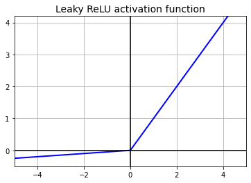

```python
def leaky_relu(z, alpha=0.01):
    return tf.maximum(alpha*z, z)

z = np.linspace(-5, 5, 200)
plt.plot(z, leaky_relu(z, 0.05), "b-", linewidth=2)
plt.plot([-5, 5], [0, 0], 'k-')
plt.plot([0, 0], [-5, 5], 'k-')
plt.grid(True)
props = dict(facecolor='black', shrink=0.1)
plt.title("Leaky ReLU activation function", fontsize=14)
plt.axis([-5, 5, -0.5, 4.2])
plt.show()
```

[figure not shown]

```python
z = np.linspace(-5, 5, 200)
with tf.GradientTape(persistent=True) as g:
    x = tf.Variable(z)
    y = leaky_relu(x, 0.05)
grads = g.gradient(y,x)
plt.plot(z, grads.numpy(), "b-", linewidth=2)
plt.plot([-5, 5], [0, 0], 'k-')
plt.plot([0, 0], [-5, 5], 'k-')
plt.grid(True)
plt.title(r"Derivative of LeakyReLU", fontsize=14)
plt.axis([-5, 5, min(0, min(grads.numpy())) - 1E-2, max(grads.numpy()) + 1E-2])
plt.show()
```

**(b) SoftPlus**

**Output Range :** 0 to Infinity

**Derivation :**

Softplus: $\text{Softplus}\left(x\right)=\text{ln}\left(1+e^{x}\right)$

Softplus: $\text{d/dx(Softplus}\left(x\right))=\text{d/dx (ln}\left(1+e^{x}\right))$

Softplus: $\text{d/dx(Softplus}\left(x\right))=\left(1/ (1+e^{x}) * \text{d/dx(}1+e^{x})\right)$

Softplus: $\text{d/dx(Softplus}\left(x\right))=\left((1/ (1+e^{x})) * e^{x}\right)$

Softplus: $\text{d/dx(Softplus}\left(x\right))=\left(e^{x}/ (1+e^{x})\right)$

[figure not shown]

```python
def softplus(x):
    return tf.math.softplus(x)

z = np.linspace(1, 5, 200)
plt.plot(z, softplus(x), "b-", linewidth=2)
plt.plot([0, 5], [0, 0], 'k-')
plt.plot([0, 0], [0, 5], 'k-')
plt.grid(True)
props = dict(facecolor='black', shrink=0.1)
plt.title("SoftPlus activation function", fontsize=14)
plt.axis([0, 5, -0.5, 4.2])
plt.show()
```

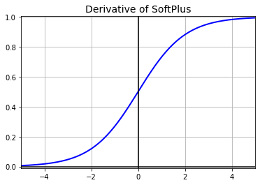

```python
z = np.linspace(-5, 5, 200)
with tf.GradientTape(persistent=True) as g:
    x = tf.Variable(z)
    y = softplus(x)
grads = g.gradient(y,x)
plt.plot(z, grads.numpy(), "b-", linewidth=2)
plt.plot([-5, 5], [0, 0], 'k-')
plt.plot([0, 0], [-5, 5], 'k-')
plt.grid(True)
plt.title(r"Derivative of SoftPlus", fontsize=14)
plt.axis([-5, 5, min(0, min(grads.numpy())) - 1E-2, max(grads.numpy()) + 1E-2])
plt.show()
```

**Numpy is possibly being used in the following questions. You need to import numpy here.**

```python
import numpy as np
```

#### **Question 1.2** **Assume that we feed a data point $x$ with a ground-truth label $y=2$ to the feed-forward neural network with the ReLU activation function as shown in the following figure**

[figure not shown]

**(a)** What is the numerical value of the latent presentation $h^1(x)$?

[1 point]

**(b)** What is the numerical value of the latent presentation $h^2(x)$?

[1 point]

**(c)** What is the numerical value of the logit $h^3(x)$?

[1 point]

**(d)** What is the corresonding prediction probabilities $p(x)$?

[1 point]

**(e)** What is the cross-entropy loss caused by the feed-forward neural network at $(x,y)$? Remind that $y=2$.

[1 point]

**(e)** Assume that we are applying the label smoothing technique (i.e., [link for main paper](https://papers.nips.cc/paper/2019/file/f1748d6b0fd9d439f71450117eba2725-Paper.pdf) from Goeff Hinton) with $\alpha = 0.1$. What is the relevant loss caused by the feed-forward neural network at $(x,y)$?

[1 point]

**You need to show both formulas and numerical results for earning full mark. Although it is optional, it is great if you show your numpy code for your computation.**

```python
def sigmoid(x):
    return 1.0/(1+np.exp(-x))
```

```python
def relu(x):
    return(np.maximum(0, x))
```

```python
def softmax(x):

    f_x = np.exp(x) / np.sum(np.exp(x))
    return f_x
```

**1.2(a)**

x = [ [1] , [-1] , [1] ]

w1 = [ [1,-1,1] , [1,-1,-1] , [2,-1,2] , [-1,-2,1] ]

b1 = [ [1] , [0] , [1] , [0] ] # expand the dimension from b1 transpose to b1

h1_bar = w1(x) + b1

```
   = [ [1,-1,1] , [1,-1,-1] , [2,-1,2] , [-1,-2,1] ] * [ [1] , [-1] , [1] ] + [ [1] , [0] , [1] , [0] ]

   = [ [4] , [1] , [6] , [2] ]
```

h1 = ReLU(h1_bar)

```
= ReLU([ [4] , [1] , [6] , [2] ])

= [ [4] , [1] , [6] , [2] ]
```

```python
# 1.2(a)
x = np.array([[1],[-1],[1]])
w1 = np.array([[1,-1,1],[1,-1,-1],[2,-1,2],[-1,-2,1]])
b1 = np.array([[1],[0],[1],[0]])

h1_bar = w1.dot(x)+b1

h1 = relu(h1_bar)
h1
```

```
array([[4],
       [1],
       [6],
       [2]])
```

**1.2(b)**

h1 = [ [4] , [1] , [6] , [2] ]

w2 = [ [1,-1,-1,2] , [1,-1,1,-1] , [-1,2,-1,2] ]

b2 = [ [1] , [1] , [0] ]

h2_bar = w2(h1) + b2

```
   = [ [1,-1,-1,2] , [1,-1,1,-1] , [-1,2,-1,2] ] * [ [4] , [1] , [6] , [2] ]
      + [ [1] , [1] , [0] ]

   = [ [2] , [8] , [-4] ]
```

h2 = ReLU(h2_bar)

```
= ReLU ([ [2] , [8] , [-4] ])

= [ [2] , [8] , [0] ]
```

```python
# 1.2(b)
w2 = np.array([[1,-1,-1,2],[1,-1,1,-1],[-1,2,-1,2]])
b2 = np.array([[1],[1],[0]])

h2_bar = w2.dot(h1)+b2

h2 = relu(h2_bar)
h2
```

```
array([[2],
       [8],
       [0]])
```

**1.2(c)**

h2 = [ [2] , [8] , [0] ]

w3 = [ [1,-2,1] , [1,2,-1] , [-1,1,-1] ]

b3 = [ [0] , [0] , [0] ]

logit = w3(h2) + b3

```
   = [ [1,-2,1] , [1,2,-1] , [-1,1,-1] ] * [ [2] , [8] , [0] ]
      + [ [0] , [0] , [0] ]

   = [ [-14] , [18] , [6] ]
```

```python
# 1.2(c)
w3 = np.array([[1,-2,1],[1,2,-1],[-1,1,-1]])
b3 = np.array([[0],[0],[0]])

logit = w3.dot(h2)+b3
logit
```

```
array([[-14],
       [ 18],
       [  6]])
```

**1.2(d)**

p = softmax(logit)

[output not shown]

```python
# 1.2(d)
p = softmax(logit)
p
```

```
array([[1.26640877e-14],
       [9.99993856e-01],
       [6.14417460e-06]])
```

**1.2(e)**

y = [0 , 1 , 0]

cross entropy loss = - [ log10(1.26640877e-14) *0 + log10(0.9999)* 1 + log10(6.14417460e-06) * 0 ]

[output not shown]

```python
# 1.2(e)
np.set_printoptions(suppress=True)
ce_loss = - ( np.log10(0.9999) )
ce_loss
```

```
4.3431619807505604e-05
```

**1.2(f)**

The cross entrophy loss will remain the same even after the label smoothing technique.

#### **Question 1.3** **Assume that we are constructing a multilayered feed-forward neural network for a classification problem with three classes where the model parameters will be generated randomly using your student ID. The architecture of this network is ($3 (Input)\rightarrow4(LeakyReLU)\rightarrow 3(Output)$) as shown in the following figure. Note that the LeakyReLU has the same formula as the one in Q1.1.**

[figure not shown]

We feed a feature vector $x=\left[\begin{array}{ccc} 1 & -1 & 1.5\end{array}\right]^{T}$ with ground-truth label $y=3$ to the above network.

**You need to show both formulas, numerical results, and your numpy code for your computation for earning full marks.**

```python
#Code to generate random matrices and biases for W1, b1, W2, b2
import numpy as np
student_id = 31939767          #insert your student id here for example 1234
np.random.seed(student_id)
W1 = np.random.rand(4,3)
b1 = np.random.rand(4,1)
W2 = np.random.rand(3,4)
b2 = np.random.rand(3,1)
```

```python
W1
```

```
array([[0.71290934, 0.03174788, 0.11150435],
       [0.21144323, 0.66495569, 0.26741047],
       [0.48240269, 0.24203924, 0.08585155],
       [0.00489806, 0.98603017, 0.06737236]])
```

```python
b1
```

```
array([[0.4009857 ],
       [0.48585421],
       [0.11870111],
       [0.02914679]])
```

```python
W2
```

```
array([[0.80295712, 0.41639852, 0.82091459, 0.69519515],
       [0.03627839, 0.20954105, 0.50321789, 0.06390601],
       [0.87678876, 0.28414257, 0.37568491, 0.54911761]])
```

```python
b2
```

```
array([[0.41446256],
       [0.14949661],
       [0.18422023]])
```

```python
def leaky_relu(z, alpha=0.01):
    return np.maximum(alpha*z, z)
```

```python
def der_leaky_relu(x, alpha=0.01):
    dx = np.ones_like(x)
    dx[x < 0] = alpha
    return dx
```

**Forward propagation**

**(a)** What is the value of $\bar{h}^{1}(x)$?

[1 point]

*Show your fomular*

**(a)**

$\bar{h}^{1}(x)$ = W1 * x + b1

```
 = [[0.71290934, 0.03174788, 0.11150435],
    [0.21144323, 0.66495569, 0.26741047],
    [0.48240269, 0.24203924, 0.08585155],
    [0.00489806, 0.98603017, 0.06737236]] * [ [1] , [-1] , [1.5] ] + [[0.4009857 ],
                                                                     [0.48585421],
                                                                     [0.11870111],
                                                                     [0.02914679]]
 = [[ 1.24940369],
    [ 0.43345745],
    [ 0.48784188],
    [-0.85092678]]
```

```python
# Show your code

x = np.array([ [1] , [-1] , [1.5] ])

h_bar1 = W1.dot(x)+b1

h_bar1
```

```
array([[ 1.24940369],
       [ 0.43345745],
       [ 0.48784188],
       [-0.85092678]])
```

**(b)** What is the value of $h^{1}(x)$?

[1 point]

*Show your fomular*

$h^{1}(x)$ = leaky_relu ( $\bar{h}^{1}(x)$)

```
       = leaky_relu( [ [ 1.24940369] , [ 0.43345745] , [ 0.48784188] , [-0.85092678] ] )

       = [ [ 1.24940369] , [ 0.43345745] , [ 0.48784188] , [-0.00850927] ]
```

```python
#Show your code

h1 = leaky_relu(h_bar1)
h1
```

```
array([[ 1.24940369],
       [ 0.43345745],
       [ 0.48784188],
       [-0.00850927]])
```

**(c)** What is the predicted value $\hat{y}$?

[1 point]

*Show your fomular*

**(c)**

predicted value = output = $h^{2}(x)$

$\bar{h}^{2}(x)$ = W2 * $h^{1}(x)$ + b2

```
             = [[0.80295712, 0.41639852, 0.82091459, 0.69519515],
                [0.03627839, 0.20954105, 0.50321789, 0.06390601],
                [0.87678876, 0.28414257, 0.37568491, 0.54911761]] * [[ 1.24940369],
                                                                     [ 0.43345745],
                                                                     [ 0.48784188],
                                                                     [-0.00850927]] + [[0.41446256],
                                                                                       [0.14949661],
                                                                                       [0.18422023]]
             = [[1.9927321 ],
                [0.53059706],
                [1.5814493 ]]
```

p = softmaxt($\bar{h}^{2}(x)$ )

```
       = softmax ( [ [1.9927321 ] , [0.53059706] , [1.5814493 ] ]

       = [ [0.52783249] , [0.12232041] , [0.34984709] ]
```

predicted y is [ 1 , 0 , 0 ]

```python
#Show your code

h_bar2 = W2.dot(h1)+b2
h2 = softmax(h_bar2)
h2
```

```
array([[0.52783249],
       [0.12232041],
       [0.34984709]])
```

**(d)** Suppose that we use the cross-entropy (CE) loss. What is the value of the CE loss $l$?

[1 point]

*Show your fomular*

**(d)**

Obtain the probability using softmax of the logit to calculate the CE Loss

logit = $\bar{h}^{2}(x)$

```
  = [[1.9927321 ],
     [0.53059706],
     [1.5814493 ]]
```

p = softmax(logit)

```
 = softmax( [ [1.9927321 ] , [0.53059706] , [1.5814493 ] ] )

 = [ [0.52783249] , [0.12232041] , [0.34984709] ]
```

CE_loss

p = [ [0.52783249] , [0.12232041] , [0.34984709] ]

q = [ 0 , 0 , 1 ] -- ground-truth label 𝑦=3

CE_loss = - [ log2(0.52783249) *0 + log2(0.12232041)* 0 + log2(0.34984709) * 1 ]

```
           = - [ log10(0.34984709) ]

           = - [ - 0.456121734163441 ]

           = 0.4561
```

```python
#Show your code

logit = h_bar2
p = softmax(logit)
p
```

```
array([[0.52783249],
       [0.12232041],
       [0.34984709]])
```

```python
ce_loss = - (np.log10(0.34984709))
ce_loss
```

```
0.456121734163441
```

**Backward propagation**

**(e)** What are the derivatives $\frac{\partial l}{\partial h^{2}},\frac{\partial l}{\partial W^{2}}$, and $\frac{\partial l}{\partial b^{2}}$?

[6 points]

**Derivation for $\frac{\partial l}{\partial h^{2}}$**

$\frac{\partial l}{\partial h^{2}}$ = $g^{2}$

= - y + softmax($h^{2}$)

= $p^{T}$ - y

# which y is the one hot vector

= [ [0.52783249, 0.12232041, 0.34984709] ] - [ 0,0,1 ]

= [ [ 0.52783249, 0.12232041, -0.65015291] ]

```python
p_t = np.transpose(p)
one_hot_vector = [0,0,1]
der_h2 = p_t - one_hot_vector
der_h2
```

```
array([[ 0.52783249,  0.12232041, -0.65015291]])
```

**Derivation for $\frac{\partial l}{\partial W^{2}}$**

$\frac{\partial l}{\partial W^{2}}$ = $\frac{\partial l}{\partial h^{2}}$ . $\frac{\partial h^{2}}{\partial W^{2}}$

= $g^{2^T}$ * $h^{1^T}$ # where $g^{2}$ = $\frac{\partial l}{\partial h^{2}}$

```
= [ [ 0.52783249] , [ 0.12232041] , [-0.65015291] ] * [ [ 1.24940369,  0.43345745,  0.48784188, -0.00850927] ] <div>

= [ [ 0.65947586,  0.22879293,  0.25749879, -0.00449147],
          [ 0.15282758,  0.0530207 ,  0.05967302, -0.00104086],
          [-0.81230344, -0.28181362, -0.31717182,  0.00553233] ] <div>
```

```python
der_h2_t = np.transpose(der_h2)

h1_t = np.transpose(h1)

der_w2 = der_h2_t.dot(h1_t)
der_w2
```

```
array([[ 0.65947586,  0.22879293,  0.25749879, -0.00449147],
       [ 0.15282758,  0.0530207 ,  0.05967302, -0.00104086],
       [-0.81230344, -0.28181362, -0.31717182,  0.00553233]])
```

**Derivation for $\frac{\partial l}{\partial b^{2}}$**

$\frac{\partial l}{\partial W^{2}}$ = $\frac{\partial l}{\partial h^{2}}$ . $\frac{\partial h^{2}}{\partial b^{2}}$

= $g^{2}$

```
 = [ [ 0.52783249,  0.12232041, -0.65015291] ]
```

**(f)** What are the derivatives $\frac{\partial l}{\partial h^{1}}, \frac{\partial l}{\partial \bar{h}^{1}},\frac{\partial l}{\partial W^{1}}$, and $\frac{\partial l}{\partial b^{1}}$?

[6 points]

**Derivation for $\frac{\partial l}{\partial h^{1}}$**

$\frac{\partial l}{\partial h^{1}}$ = $\frac{\partial l}{\partial h^{2}}$ . $\frac{\partial h^{2}}{\partial h^{1}}$

= $g^{2}$ . $W^{2}$

```
= [ [ 0.52783249,  0.12232041, -0.65015291] ] * [ [0.80295712, 0.41639852, 0.82091459, 0.69519515],
                                                  [0.03627839, 0.20954105, 0.50321789, 0.06390601],
                                                  [0.87678876, 0.28414257, 0.37568491, 0.54911761] ]

= [[-0.14178231,  0.0606837 ,  0.25060658,  0.01775319]]
```

```python
der_h1 = der_h2.dot(W2)
der_h1
```

```
array([[-0.14178231,  0.0606837 ,  0.25060658,  0.01775319]])
```

**Derivation for $\frac{\partial l}{\partial \bar h^{1}}$**

$\frac{\partial l}{\partial \bar h^{1}}$ = $\frac{\partial l}{\partial h^{1}}$ . $\frac{\partial h^{1}}{\partial\bar h^{1}}$

= $\frac{\partial l}{\partial h^{1}}$ * $\frac{\partial h^{1}}{\partial \bar h^{1}}$

= $\frac{\partial l}{\partial h^{1}}$ * diag(der_leaky_relu( $\bar h^{1}$ ))

```
 = [ [-0.14178231,  0.0606837 ,  0.25060658,  0.01775319] ] * [ [1.  , 0.  , 0.  , 0.  ],
                                                                [0.  , 1.  , 0.  , 0.  ],
                                                                [0.  , 0.  , 1.  , 0.  ],
                                                                [0.  , 0.  , 0.  , 0.01]]

 = [ [-0.14178231,  0.0606837 ,  0.25060658,  0.00017753] ]
```

```python
np.diag(np.transpose(der_leaky_relu(h_bar1))[0])
```

```
array([[1.  , 0.  , 0.  , 0.  ],
       [0.  , 1.  , 0.  , 0.  ],
       [0.  , 0.  , 1.  , 0.  ],
       [0.  , 0.  , 0.  , 0.01]])
```

```python
np.set_printoptions(suppress=True) # to remove scientific notation in the matrix

der_h_bar2 = np.diag(tf.transpose(der_leaky_relu(h_bar1))[0])
der_h_bar1 = der_h1.dot(der_h_bar2)
der_h_bar1
```

```
array([[-0.14178231,  0.0606837 ,  0.25060658,  0.00017753]])
```

**Derivation for $\frac{\partial l}{\partial W^{1}}$**

$\frac{\partial l}{\partial W^{1}}$ = $\frac{\partial l}{\partial \bar h^{1}}^{T}$ . $h^{0^T}$

```
= [ [-0.14178231] , [ 0.0606837 ] , [ 0.25060658] , [ 0.01775319] ] * [ [ 1. , -1. ,  1.5] ]

= [[-0.14178231,  0.14178231, -0.21267347],
   [ 0.0606837 , -0.0606837 ,  0.09102555],
   [ 0.25060658, -0.25060658,  0.37590987],
   [ 0.00017753, -0.00017753,  0.0002663 ]]
```

```python
der_h_bar1_t = np.transpose(der_h_bar1)
der_h_bar1_t
```

```
array([[-0.14178231],
       [ 0.0606837 ],
       [ 0.25060658],
       [ 0.00017753]])
```

```python
x_t = np.transpose(x)
x_t
```

```
array([[ 1. , -1. ,  1.5]])
```

```python
der_w1 = der_h_bar1_t.dot(x_t)
der_w1
```

```
array([[-0.14178231,  0.14178231, -0.21267347],
       [ 0.0606837 , -0.0606837 ,  0.09102555],
       [ 0.25060658, -0.25060658,  0.37590987],
       [ 0.00017753, -0.00017753,  0.0002663 ]])
```

**Derivation for $\frac{\partial l}{\partial b^{1}}$**

$\frac{\partial l}{\partial b^{1}}$ = $\frac{\partial l}{\partial h^{1}}$ . $\frac{\partial h^{1}}{\partial b^{1}}$

= $\bar g^{1}$

= $\frac{\partial l}{\partial \bar h^{1}}$

```
 = [ [-0.14178231,  0.0606837 ,  0.25060658,  0.00017753] ]
```

**SGD update**

**(g)** Assume that we use SGD with learning rate $\eta=0.01$ to update the model parameters. What are the values of $W^2, b^2$ and $W^1, b^1$ after updating?

[5 points]

*Show your fomular*

$W = W - \eta*\frac{\partial l}{\partial W}$ where $\eta >0$ is the learning rate.

Hence, in this cate the rate is 0.01

W1_new

[output not shown]

W2_new

[output not shown]

$b^{1}$ = [[0.4009857 ], [0.48585421], [0.11870111], [0.02914679]]

$b^{2}$ = [[0.41446256], [0.14949661], [0.18422023]]

```python
#Show your code
rate = 0.01
W1_new = W1 - rate
W2_new = W2 - rate

print(W1_new)
print(W2_new)
```

```
[[ 0.70290934  0.02174788  0.10150435]
 [ 0.20144323  0.65495569  0.25741047]
 [ 0.47240269  0.23203924  0.07585155]
 [-0.00510194  0.97603017  0.05737236]]
[[0.79295712 0.40639852 0.81091459 0.68519515]
 [0.02627839 0.19954105 0.49321789 0.05390601]
 [0.86678876 0.27414257 0.36568491 0.53911761]]
```

## Part 2: Deep Neural Networks (DNN)

[Total marks for this part: 30 points]

The first part of this assignment is for you to demonstrate your basis knowledge in deep learning that you have acquired from the lectures and tutorials materials. Most of the contents in this assignment are drawn from **the tutorials covered from weeks 1 to 4**. Going through these materials before attempting this assignment is highly recommended.

In the first part of this assignment, you are going to work with the **FashionMNIST** dataset for *image recognition task*. It has the exact same format as MNIST (70,000 grayscale images of 28 × 28 pixels each with 10 classes), but the images represent fashion items rather than handwritten digits, so each class is more diverse, and the problem is significantly more challenging than MNIST.

#### **Question 2.1**. Load the Fashion MNIST using Keras datasets

[5 points]

We first use keras incoporated in TensorFlow 2.x for loading the training and testing sets.

```python
import tensorflow as tf
from tensorflow import keras
```

```python
tf.random.set_seed(1234)
```

We first use keras datasets in TF 2.x to load Fashion MNIST dataset.

```python
fashion_mnist = keras.datasets.fashion_mnist
(X_train_full_img, y_train_full), (X_test_img, y_test) = fashion_mnist.load_data()
```

The shape of X_train_full_img is $(60000, 28, 28 )$ and that of X_test_img is $(10000, 28, 28)$. We next convert them to matrices of vectors and store in X_train_full and X_test.

```python
num_train = X_train_full_img.shape[0]
num_test = X_test_img.shape[0]

X_train_full = X_train_full_img.reshape(num_train,-1)
X_test = X_test_img.reshape(num_test, -1)

print(X_train_full.shape, y_train_full.shape)
print(X_test.shape, y_test.shape)
```

```
(60000, 784) (60000,)
(10000, 784) (10000,)
```

#### **Question 2.2**. Preprocess the dataset and split into training, validation, and testing datasets

[5 points]

You need to write the code to address the following requirements:

- Print out the dimensions of X_train_full and X_test
- Use $10 \%$ of X_train_full for validation and the rest of X_train_full for training. This splits X_train_full and y_train_full into X_train, y_train ($90 \%$) and X_valid, y_valid ($10 \%$).
- Finally, scale the pixels of X_train, X_valid, and X_test to $[0,1]$) (i.e., $X = X/255.0$).

You have now the separate training, validation, and testing sets for training your model.

```python
import math

N = X_train_full.shape[0]
i = math.floor(0.9*N)
X_train, y_train = X_train_full[:i ], y_train_full[:i]
X_valid, y_valid = X_train_full[i:], y_train_full[i:]
X_train, X_valid, X_test = X_train/255.0, X_valid/255.0, X_test/255.0
```

#### **Question 2.3**. Visualize some images in the training set with labels

[5 points]

You are required to write the code to show **random** $36$ images in X_train_full_img (which is an array of images) with labels as in the following figure. Note that the class names of Fashion MNIST are as follows

- "1:T-shirt/top", "2:Trouser", "3:Pullover", "4:Dress", "5:Coat", "6:Sandal", "7:Shirt", "8:Sneaker", "9:Bag", "10:Ankle boot"

[figure not shown]

```python
import matplotlib.pyplot as plt
%matplotlib inline
```

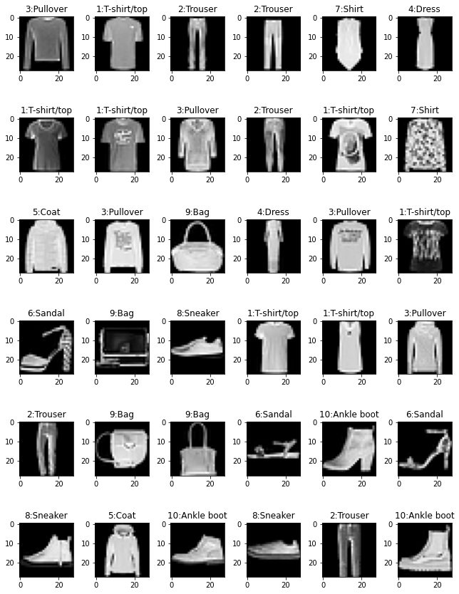

```python
# YOU ARE REQUIRED TO INSERT YOUR CODES IN THIS CELL
from random import randint



# specify the number of rows and columns you want to see
num_row = 6
num_col = 6

# get a segment of the dataset
images = X_train_full_img
labels = y_train_full

labels_name = ["1:T-shirt/top", "2:Trouser", "3:Pullover", "4:Dress", "5:Coat", "6:Sandal", "7:Shirt", "8:Sneaker", "9:Bag", "10:Ankle boot"]

# plot images
fig, axes = plt.subplots(num_row, num_col, figsize=(1.5*num_col,2*num_row))
for i in range(num_row*num_col):
    index = randint(0,X_train_full_img.shape[0])
    ax = axes[i//num_col, i%num_col]
    ax.imshow(images[index], cmap='gray')
    ax.set_title('{}'.format(labels_name[labels[index]]) )
plt.tight_layout()
plt.show()
```

#### **Question 2.4**. Write code for the feed-forward neural net using TF 2.x

[5 points]

We now develop a feed-forward neural network with the architecture $784 \rightarrow 20(ReLU) \rightarrow 40(ReLU) \rightarrow 10(softmax)$. You can choose your own way to implement your network and an optimizer of interest. You should train model in $20$ epochs and evaluate the trained model on the test set.

```python
#Insert your code here and you can add more cells if necessary
import tensorflow as tf
from tensorflow.keras.layers import Dense, Flatten
from tensorflow.keras.models import Sequential

dnn_model = Sequential()
dnn_model.add(Dense(units=20,  input_shape=(784,), activation='relu'))
dnn_model.add(Dense(units=40, activation='relu'))
dnn_model.add(Dense(units=10, activation='softmax'))

dnn_model.build()
dnn_model.summary()
```

```
Model: "sequential"
_________________________________________________________________
Layer (type)                 Output Shape              Param #
=================================================================
dense (Dense)                (None, 20)                15700
_________________________________________________________________
dense_1 (Dense)              (None, 40)                840
_________________________________________________________________
dense_2 (Dense)              (None, 10)                410
=================================================================
Total params: 16,950
Trainable params: 16,950
Non-trainable params: 0
_________________________________________________________________
```

```python
opt = tf.keras.optimizers.SGD(learning_rate=0.001)
dnn_model.compile(optimizer=opt,
                  loss='sparse_categorical_crossentropy',
                  metrics=['accuracy'])
```

```python
from tensorflow import keras
logdir = "tf_logs/"

# Init a tensorboard_callback
tensorboard_callback = keras.callbacks.TensorBoard(log_dir=logdir)

# Call the fit method, passing the tensorboard_callback
history = dnn_model.fit(x=X_train, y=y_train, batch_size=32,
                        epochs=20,
                        validation_data=(X_valid, y_valid),
                       callbacks=[tensorboard_callback])
```

```
Instructions for updating:
use `tf.profiler.experimental.stop` instead.
```

```python
dnn_model.evaluate(X_test, y_test)
```

```
[0.5123465061187744, 0.8227999806404114]
```

#### **Question 2.5**. Tuning hyper-parameters with grid search

[5 points]

Assume that you need to tune the number of neurons on the first and second hidden layers $n_1 \in \{20, 40\}$, $n_2 \in \{20, 40\}$ and the used activation function $act \in \{sigmoid, tanh, relu\}$. The network has the architecture pattern $784 \rightarrow n_1 (act) \rightarrow n_2(act) \rightarrow 10(softmax)$ where $n_1, n_2$, and $act$ are in their grides. Write the code to tune the hyper-parameters $n_1, n_2$, and $act$. Note that you can freely choose the optimizer and learning rate of interest for this task.

```python
import numpy as np

list_activation = ['sigmoid','tanh','relu']
list_n1 = [20,40]
list_n2 = [20,40]

best_acc= - np.inf
best_history = None
dnn_model = Sequential()
opt = tf.keras.optimizers.SGD(learning_rate=0.01)

for act in list_activation:
    for n1 in list_n1:
        for n2 in list_n2:
            dnn_model.add(Dense(units=n1,  input_shape=(784,), activation=act))
            dnn_model.add(Dense(units=n2, activation=act))
            dnn_model.add(Dense(units=10, activation='softmax'))

            dnn_model.build()

            dnn_model.compile(optimizer=opt,
                              loss='sparse_categorical_crossentropy',
                              metrics=['accuracy'])

            print("Training with n1 = {}, n2 = {} , activation function = {}".format(n1,n2,act))
            history = dnn_model.fit(x=X_train, y=y_train, batch_size=32, epochs=20, verbose = 0)

            valid_loss, valid_acc = dnn_model.evaluate(X_test, y_test)
            print('\tvalid acc = {}, valid loss = {}'.format(valid_acc, valid_loss))
            if(valid_acc > best_acc):
                best_acc = valid_acc
                best_model = dnn_model
                best_n1 = n1
                best_n2 = n2
                best_act = act
                best_history = history

print('\nThe best model is with with n1 = {}, n2 = {} , activation function = {}'.format(best_n1,best_n2,best_act))
```

```
Training with n1 = 20, n2 = 20 , activation function = sigmoid
	valid acc = 0.8059999942779541, valid loss = 0.5410276055335999
Training with n1 = 20, n2 = 40 , activation function = sigmoid
	valid acc = 0.8039000034332275, valid loss = 0.6524294018745422
Training with n1 = 40, n2 = 20 , activation function = sigmoid
	valid acc = 0.7558000087738037, valid loss = 0.6853846907615662
Training with n1 = 40, n2 = 40 , activation function = sigmoid
	valid acc = 0.7608000040054321, valid loss = 0.6743740439414978
Training with n1 = 20, n2 = 20 , activation function = tanh
	valid acc = 0.8385999798774719, valid loss = 0.5189242959022522
Training with n1 = 20, n2 = 40 , activation function = tanh
	valid acc = 0.8547999858856201, valid loss = 0.4630485773086548
Training with n1 = 40, n2 = 20 , activation function = tanh
	valid acc = 0.848800003528595, valid loss = 0.48590561747550964
Training with n1 = 40, n2 = 40 , activation function = tanh
	valid acc = 0.8597000241279602, valid loss = 0.44413310289382935
Training with n1 = 20, n2 = 20 , activation function = relu
	valid acc = 0.8406999707221985, valid loss = 0.5059936046600342
Training with n1 = 20, n2 = 40 , activation function = relu
	valid acc = 0.10000000149011612, valid loss = 2.307485818862915
Training with n1 = 40, n2 = 20 , activation function = relu
	valid acc = 0.10000000149011612, valid loss = 2.3026323318481445
Training with n1 = 40, n2 = 40 , activation function = relu
	valid acc = 0.10000000149011612, valid loss = 2.302633285522461

The best model is with with n1 = 40, n2 = 40 , activation function = tanh
```

#### **Question 2.6**. Experimenting with **the label smoothing** technique

[5 points]

Implement the label smoothing technique (i.e., [link for main paper](https://papers.nips.cc/paper/2019/file/f1748d6b0fd9d439f71450117eba2725-Paper.pdf) from Goeff Hinton) by yourself. Note that you cannot use the built-in label-smoothing loss function in TF2.x. Try the label smoothing technique with $\alpha =0.1, 0.15, 0.2$ and report the performances. You need to examine the label smoothing technique with the best architecture obtained in **Question 2.5**.

```python
#Insert your code here. You can add more cells if necessary

def smooth_labels(labels, alpha):

    labels *= (1 - alpha)
    labels += (alpha / 10)

    return labels
```

```python
onehot_vector = list()
for value in y_train:
    vector = [0 for _ in range(len(y_train))]
    vector[value] = 1
    onehot_vector.append(vector)
```

```python
def label_smoothing(inputs, epsilon=0.2):

    K = inputs.get_shape().as_list()[-1] # number of channels
    res  = ((1-epsilon) * inputs) + (epsilon / K)
    return res.numpy()
```

```python
y_train_t = y_train
y_train_t = tf.convert_to_tensor(y_train_t,tf.float32)

y_valid_t = y_valid
y_valid_t = tf.convert_to_tensor(y_valid_t,tf.float32)
```

```python
dnn_model = Sequential()
dnn_model.add(Dense(units=20,  input_shape=(784,), activation='relu'))
dnn_model.add(Dense(units=40, activation='relu'))
dnn_model.add(Dense(units=10, activation='softmax'))

dnn_model.build()

opt = tf.keras.optimizers.SGD(learning_rate=1)
dnn_model.compile(optimizer=opt,
                  loss='sparse_categorical_crossentropy',
                  metrics=['accuracy'])

logdir = "tf_logs/"

# Init a tensorboard_callback
tensorboard_callback = keras.callbacks.TensorBoard(log_dir=logdir)
# Call the fit method, passing the tensorboard_callback
history = dnn_model.fit(x=X_train, y= label_smoothing(y_train_t), batch_size=32,
                        epochs=20,
                        validation_data=(X_valid, label_smoothing(y_valid_t)),
                       callbacks=[tensorboard_callback])
```

[output not shown]

[output cut: 103 more lines]

[output not shown]

## Part 3: Convolutional Neural Networks and Image Classification

[Total marks for this part: 40 points]

**This part of the asssignment is designed to assess your knowledge and coding skill with Tensorflow as well as hands-on experience with training Convolutional Neural Network (CNN).**

**The dataset we use for this part is a small animal dataset consisting of $5,000$ images of cats, dogs, fishes, lions, chickens, elephants, butterflies, cows, spiders, and horses, each of which has 500 images. You can download the dataset at [download here](https://drive.google.com/file/d/1bEwEx72lLrjY_Idj_FgV22atIdjtCV66/view?usp=sharing) and then decompress to the folder `datasets\Animals` in your assignment folder.**

**Your task is to build a CNN model using *TF 2.x* to classify these animals. You're provided with the module models.py, which you can find in the assignment folder, with some of the following classes:**

1. `AnimalsDatasetManager`: Support with loading and spliting the dataset into the train-val-test sets. It also supports generating next batches for training. `AnimalsDatasetManager` will be passed to CNN model for training and testing.
2. `DefaultModel`: A base class for the CNN model.
3. `YourModel`: The class you'll need to implement for building your CNN model. It inherits some useful attributes and functions from the base class `DefaultModel`

Firstly, we need to run the following cells to load and preprocess the Animal dataset.

```python
%load_ext autoreload
%autoreload 2
```

Install the package `imutils` if you have not installed yet

```python
! pip install imutils
```

```python
import os
import matplotlib.pyplot as plt
plt.style.use('ggplot')
%matplotlib inline
import models
from models import SimplePreprocessor, AnimalsDatasetManager, DefaultModel
```

```python
def create_label_folder_dict(adir):
    sub_folders= [folder for folder in os.listdir(adir)
                  if os.path.isdir(os.path.join(adir, folder))]
    label_folder_dict= dict()
    for folder in sub_folders:
        item= {folder: os.path.abspath(os.path.join(adir, folder))}
        label_folder_dict.update(item)
    return label_folder_dict
```

```python
label_folder_dict= create_label_folder_dict("./datasets/Animals")
```

The below code helps to create a data manager that contains all relevant methods used to manage and process the experimental data.

```python
sp = SimplePreprocessor(width=32, height=32)
data_manager = AnimalsDatasetManager([sp])
data_manager.load(label_folder_dict, verbose=100)
data_manager.process_data_label()
data_manager.train_valid_test_split()
```

```
butterfiles 500
Processed 100/500
Processed 200/500
Processed 300/500
Processed 400/500
Processed 500/500
cats 501
Processed 100/500
Processed 200/500
Processed 300/500
Processed 400/500
Processed 500/500
chickens 500
Processed 100/500
Processed 200/500
Processed 300/500
Processed 400/500
Processed 500/500
cows 500
Processed 100/500
Processed 200/500
Processed 300/500
Processed 400/500
Processed 500/500
dogs 501
Processed 100/500
Processed 200/500
Processed 300/500
Processed 400/500
Processed 500/500
elephants 500
Processed 100/500
Processed 200/500
Processed 300/500
Processed 400/500
Processed 500/500
fishes 500
Processed 100/500
Processed 200/500
Processed 300/500
Processed 400/500
Processed 500/500
horses 500
Processed 100/500
Processed 200/500
Processed 300/500
Processed 400/500
Processed 500/500
lions 500
Processed 100/500
Processed 200/500
Processed 300/500
Processed 400/500
Processed 500/500
spiders 500
Processed 100/500
Processed 200/500
Processed 300/500
Processed 400/500
Processed 500/500
```

Note that the object `data_manager` has the attributes relating to *the training, validation, and testing sets* as shown belows. You can use them in training your developped models in the sequel.

```python
print(data_manager.X_train.shape, data_manager.y_train.shape)
print(data_manager.X_valid.shape, data_manager.y_valid.shape)
print(data_manager.X_test.shape, data_manager.y_test.shape)
print(data_manager.classes)
```

```
(4000, 32, 32, 3) (4000,)
(500, 32, 32, 3) (500,)
(500, 32, 32, 3) (500,)
['butterfiles' 'cats' 'chickens' 'cows' 'dogs' 'elephants' 'fishes'
 'horses' 'lions' 'spiders']
```

We now run the **default model** built in the **models.py** file which serves as a basic baseline to start the investigation. Follow the following steps to realize how to run a model and know the built-in methods associated to a model developped in the DefaultModel class.

We first initialize a default model from the DefaultModel class. Basically, we can define the relevant parameters of training a model including `num_classes`, `optimizer`, `learning_rate`, `batch_size`, and `num_epochs`.

```python
network1 = DefaultModel(name='network1',
                       num_classes=len(data_manager.classes),
                       optimizer='sgd',
                       batch_size= 128,
                       num_epochs = 20,
                       learning_rate=0.5)
```

The method `build_cnn()` assists us in building your convolutional neural network. You can view the code (in the **models.py** file) of the model behind a default model to realize how simple it is. Additionally, the method `summary()` shows the architecture of a model.

```python
network1.build_cnn()
network1.summary()
```

```
Model: "sequential_4"
_________________________________________________________________
Layer (type)                 Output Shape              Param #
=================================================================
conv2d (Conv2D)              (None, 32, 32, 32)        896
_________________________________________________________________
conv2d_1 (Conv2D)            (None, 32, 32, 32)        9248
_________________________________________________________________
average_pooling2d (AveragePo (None, 16, 16, 32)        0
_________________________________________________________________
conv2d_2 (Conv2D)            (None, 16, 16, 64)        18496
_________________________________________________________________
conv2d_3 (Conv2D)            (None, 16, 16, 64)        36928
_________________________________________________________________
average_pooling2d_1 (Average (None, 8, 8, 64)          0
_________________________________________________________________
flatten (Flatten)            (None, 4096)              0
_________________________________________________________________
dense_42 (Dense)             (None, 10)                40970
=================================================================
Total params: 106,538
Trainable params: 106,538
Non-trainable params: 0
_________________________________________________________________
None
```

To train a model regarding to the datasets stored in `data_manager`, you can invoke the method `fit()` for which you can specify the batch size and number of epochs for your training.

```python
network1.fit(data_manager, batch_size = 64, num_epochs = 20)
```

Here you can compute the accuracy of your trained model with respect to a separate testing set.

```python
network1.compute_accuracy(data_manager.X_test, data_manager.y_test)
```

```
0.10400000214576721
```

Below shows how you can inspect the training progress.

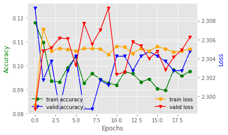

```python
network1.plot_progress()
```

You can use the method `predict()` to predict labels for data examples in a test set.

```python
network1.predict(data_manager.X_test[0:10])
```

```
array([6, 6, 6, 6, 6, 6, 6, 6, 6, 6], dtype=int64)
```

Finally, the method `plot_prediction()` visualizes the predictions for a test set in which several images are chosen to show the predictions.

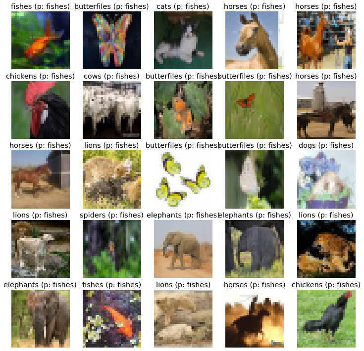

```python
network1.plot_prediction(data_manager.X_test, data_manager.y_test, data_manager.classes)
```

**Question 3.1** **After running the above cells to train the default model and observe the learning curve. Report your observation (i.e. did the model learn well? if not, what is the problem? What would you do to improve it?). Write your answer below.**

[4 points]

**Answer for Q3.1**

According to my observation on the results and performance of the model above, the model do not actually learn well as the model is having a rather accuray and high loss for both training and validation dataset.

The possible problem is insufficient number of concolutional layers, and nuerons in each layer and hence resulting in high bias.

One of the possible way to improve the model is to increase the number of convolutional layers and neurons in each of the layers and also perform batch normalisation to normalise the data and hence decrease the bias in order to improve the performance of the model in terms of accuracy and loss.

**For questions 3.2 to 3.9, you'll need to write your own model in a way that makes it easy for you to experiment with different architectures and parameters. The goal is to be able to pass the parameters to initialize a new instance of `YourModel` to build different network architectures with different parameters. Below are descriptions of some parameters for `YourModel`, which you can find in function `__init__()` for the class `DefaultModel`:**

1. `num_blocks`: an integer specifying the number of blocks in our network. Each block has the pattern `[conv, batch norm, activation, conv, batch norm, activation, mean pool, dropout]`. All convolutional layers have filter size $(3, 3)$, strides $(1, 1)$ and 'SAME' padding, and all mean pool layers have strides $(2, 2)$ and 'SAME' padding. The network will consists of a few blocks before applying a linear layer to output the logits for the softmax layer.
2. `feature_maps`: the number of feature maps in the first block of the network. The number of feature_maps will double in each of the following block. To make it convenient for you, we already calculated the number of feature maps for each block for you in line $106$
3. `drop_rate`: the keep probability for dropout. Setting `drop_rate` to $0.0$ means not using dropout.
4. `batch_norm`: the batch normalization function is used or not. Setting `batch_norm` to `None` means not using batch normalization.
5. The `skip connection` is added to the output of the second `batch norm`. Additionally, your class has a boolean property (i.e., instance variable) named `use_skip`. If `use_skip=True`, the skip connectnion is enable. Otherwise, if `use_skip=False`, the skip connectnion is disable.

Below is the architecture of one block:

[figure not shown]

Below is the architecture of the entire deep net with `two blocks`:

[figure not shown]

Here we assume that the first block has `feature_maps = feature_maps[0] = 32`. Note that the initial number of feature maps of the first block is declared in the instance variable `feature_maps` and is multiplied by $2$ in each follpwing block.

```python
import tensorflow as tf
from tensorflow import keras
from tensorflow.keras import layers, models
```

```python
tf.random.set_seed(1234)
```

**Question 3.2** **Write the code of the `YourModel` class here. Note that this class will inherit from the `DefaultModel` class. You'll only need to re-write the code for the `build_cnn` method in the `YourModel` class from the cell below. Note that the `YourModel` class is inherited from the `DefaultModel` class.**

[4 points]

```python
class YourModel(DefaultModel):
    def __init__(self,
                 name='network1',
                 width=32, height=32, depth=3,
                 num_blocks=2,
                 feature_maps=32,
                 num_classes=4,
                 drop_rate=0.2,
                 batch_norm = None,
                 is_augmentation = False,
                 activation_func='relu',
                 use_skip = True,
                 optimizer='adam',
                 batch_size=10,
                 num_epochs= 20,
                 learning_rate=0.0001,
                 verbose= True):
        super(YourModel, self).__init__(name, width, height, depth, num_blocks, feature_maps, num_classes, drop_rate, batch_norm, is_augmentation,
                                        activation_func, use_skip, optimizer, batch_size, num_epochs, learning_rate, verbose)

    def build_cnn(self):
        #Insert your code here
        self.model = models.Sequential()
        for count in range(self.num_blocks) :
            if self.use_skip:
                self.model.add(layers.Conv2D(self.feature_maps[0], (3,3), padding='same', input_shape=(self.width, self.height, self.depth)))
            else:
                self.model.add(layers.Conv2D(self.feature_maps[0], (3,3), padding='same', input_shape=(self.width, self.height, self.depth)))
                self.model.add(layers.BatchNormalization())
                self.model.add(layers.Activation(self.activation_func))
                self.model.add(layers.Conv2D(self.feature_maps[0], (3,3), padding='same'))
                self.model.add(layers.BatchNormalization())
            self.model.add(layers.Activation(self.activation_func))
            self.model.add(layers.AveragePooling2D(pool_size=(2, 2), padding='same'))
            self.model.add(layers.Dropout(rate=self.drop_rate))
        self.model.add(layers.Flatten())
        self.model.add(layers.Dense(self.num_classes, activation='softmax'))
        self.model.compile(optimizer=self.optimizer, loss='sparse_categorical_crossentropy', metrics=['accuracy'])
```

**Question 3.3** **Once writing your own model, you need to compare two cases: (i) *using the skip connection* and (ii) *not using the skip connection*. You should set the instance variable `use_skip` to either `True` or `False`. For your runs, report which case is better and if you confront overfitting in training.**

[6 points]

**Answer for Q3.3**

The performance of the model with use_skip = False is much more better than the model with use_skip = True.

In this specific case, the model has multiple hidden layers according to the number of blocks. Hence, the chances for overfitting is very high and by enabling the skip connection, the model can skip through some of the convolutional layers and normalisation processes and hence prevent the model to be overtrained by the training data.

However, when we observe the accuracy of the 2 models, we can notice that in this case, the multiple hidden layers do not lead to overfitting problem while they can be considered suitable for the model to train the existing training dataset. Hence, according to the current training dataset, skip connection may not be neccessary as the model was not overtrained by the training dataset.

```python
our_network_skip = YourModel(name='network1',
                     feature_maps=32,
                     num_classes=len(data_manager.classes),
                     num_blocks=3,
                     drop_rate= 0.0,
                     batch_norm=True,
                     use_skip = True,
                     optimizer='adam',
                     learning_rate= 0.001)
our_network_skip.build_cnn()
our_network_skip.summary()
```

```
Model: "sequential_6"
_________________________________________________________________
Layer (type)                 Output Shape              Param #
=================================================================
conv2d_4 (Conv2D)            (None, 32, 32, 32)        896
_________________________________________________________________
activation (Activation)      (None, 32, 32, 32)        0
_________________________________________________________________
average_pooling2d_2 (Average (None, 16, 16, 32)        0
_________________________________________________________________
dropout (Dropout)            (None, 16, 16, 32)        0
_________________________________________________________________
conv2d_5 (Conv2D)            (None, 16, 16, 32)        9248
_________________________________________________________________
activation_1 (Activation)    (None, 16, 16, 32)        0
_________________________________________________________________
average_pooling2d_3 (Average (None, 8, 8, 32)          0
_________________________________________________________________
dropout_1 (Dropout)          (None, 8, 8, 32)          0
_________________________________________________________________
conv2d_6 (Conv2D)            (None, 8, 8, 32)          9248
_________________________________________________________________
activation_2 (Activation)    (None, 8, 8, 32)          0
_________________________________________________________________
average_pooling2d_4 (Average (None, 4, 4, 32)          0
_________________________________________________________________
dropout_2 (Dropout)          (None, 4, 4, 32)          0
_________________________________________________________________
flatten_1 (Flatten)          (None, 512)               0
_________________________________________________________________
dense_43 (Dense)             (None, 10)                5130
=================================================================
Total params: 24,522
Trainable params: 24,522
Non-trainable params: 0
_________________________________________________________________
None
```

```python
our_network_skip.fit(data_manager, batch_size=32, num_epochs=20)
```

```python
our_network_skip.compute_accuracy(data_manager.X_test, data_manager.y_test)
```

```
0.550000011920929
```

```python
our_network_no_skip = YourModel(name='network1',
                     feature_maps=32,
                     num_classes=len(data_manager.classes),
                     num_blocks=3,
                     drop_rate= 0.0,
                     batch_norm=True,
                     use_skip = False,
                     optimizer='adam',
                     learning_rate= 0.001)
our_network_no_skip.build_cnn()
our_network_no_skip.summary()
```

```
Model: "sequential_8"
_________________________________________________________________
Layer (type)                 Output Shape              Param #
=================================================================
conv2d_7 (Conv2D)            (None, 32, 32, 32)        896
_________________________________________________________________
batch_normalization (BatchNo (None, 32, 32, 32)        128
_________________________________________________________________
activation_3 (Activation)    (None, 32, 32, 32)        0
_________________________________________________________________
conv2d_8 (Conv2D)            (None, 32, 32, 32)        9248
_________________________________________________________________
batch_normalization_1 (Batch (None, 32, 32, 32)        128
_________________________________________________________________
activation_4 (Activation)    (None, 32, 32, 32)        0
_________________________________________________________________
average_pooling2d_5 (Average (None, 16, 16, 32)        0
_________________________________________________________________
dropout_3 (Dropout)          (None, 16, 16, 32)        0
_________________________________________________________________
conv2d_9 (Conv2D)            (None, 16, 16, 32)        9248
_________________________________________________________________
batch_normalization_2 (Batch (None, 16, 16, 32)        128
_________________________________________________________________
activation_5 (Activation)    (None, 16, 16, 32)        0
_________________________________________________________________
conv2d_10 (Conv2D)           (None, 16, 16, 32)        9248
_________________________________________________________________
batch_normalization_3 (Batch (None, 16, 16, 32)        128
_________________________________________________________________
activation_6 (Activation)    (None, 16, 16, 32)        0
_________________________________________________________________
average_pooling2d_6 (Average (None, 8, 8, 32)          0
_________________________________________________________________
dropout_4 (Dropout)          (None, 8, 8, 32)          0
_________________________________________________________________
conv2d_11 (Conv2D)           (None, 8, 8, 32)          9248
_________________________________________________________________
batch_normalization_4 (Batch (None, 8, 8, 32)          128
_________________________________________________________________
activation_7 (Activation)    (None, 8, 8, 32)          0
_________________________________________________________________
conv2d_12 (Conv2D)           (None, 8, 8, 32)          9248
_________________________________________________________________
batch_normalization_5 (Batch (None, 8, 8, 32)          128
_________________________________________________________________
activation_8 (Activation)    (None, 8, 8, 32)          0
_________________________________________________________________
average_pooling2d_7 (Average (None, 4, 4, 32)          0
_________________________________________________________________
dropout_5 (Dropout)          (None, 4, 4, 32)          0
_________________________________________________________________
flatten_2 (Flatten)          (None, 512)               0
_________________________________________________________________
dense_44 (Dense)             (None, 10)                5130
=================================================================
Total params: 53,034
Trainable params: 52,650
Non-trainable params: 384
_________________________________________________________________
None
```

```python
our_network_no_skip.fit(data_manager, batch_size=32, num_epochs=20)
```

```python
our_network_no_skip.compute_accuracy(data_manager.X_test, data_manager.y_test)
```

```
0.6100000143051147
```

**Question 3.4** **Now, let us tune the $num\_blocks \in \{2,3,4\}$, $use\_skip \in \{True, False\}$, and $learning\_rate \in \{0.001, 0.0001\}$. Write your code for this tuning and report the result of the best model on the testing set. Note that you need to show your code for tuning and evaluating on the test set to earn the full marks. During tuning, you can set the instance variable `verbose` of your model to `False` for not showing the training details of each epoch.**

[4 points]

# *Report the best parameters and the testing accuracy here*

The best model is with with num_block = 4, use_skip = False , learning_rate = 0.001

The accuracy is 0.6380000114440918 which is highest among the all.

```python
#Insert your code here. You can add more cells if necessary
import numpy as np

num_blocks_lst = [2,3,4]
use_skip_lst = [True,False]
learning_rate_lst = [0.001,0.0001]
best_acc= - np.inf
best_history = None

for num_block in num_blocks_lst:
    for us in use_skip_lst:
        for lr in learning_rate_lst:
            network_tuning = YourModel(name='network1',
                                 feature_maps=32,
                                 num_classes=len(data_manager.classes),
                                 num_blocks=num_block,
                                 drop_rate= 0.0,
                                 batch_norm=True,
                                 use_skip = us,
                                 optimizer='adam',
                                 learning_rate= lr,
                                 verbose= False)
            network_tuning.build_cnn()
            history = network_tuning.fit(data_manager, batch_size=32, num_epochs=20)

            acc = network_tuning.compute_accuracy(data_manager.X_test, data_manager.y_test)
            print('\t The accuracy of model with num_block = {}, use_skip = {} , learning_rate = {} is {}'.format(num_block,us,lr,acc))
            if(acc > best_acc):
                best_acc = acc
                best_model = network_tuning
                best_num_block = num_block
                best_us = us
                best_lr = lr
                best_history = history

print('\nThe best model is with with num_block = {}, use_skip = {} , learning_rate = {}'.format(best_num_block,best_us,best_lr))
```

```
	 The accuracy of model with num_block = 2, use_skip = True , learning_rate = 0.001 is 0.5180000066757202
	 The accuracy of model with num_block = 2, use_skip = True , learning_rate = 0.0001 is 0.42800000309944153
	 The accuracy of model with num_block = 2, use_skip = False , learning_rate = 0.001 is 0.6320000290870667
	 The accuracy of model with num_block = 2, use_skip = False , learning_rate = 0.0001 is 0.5899999737739563
	 The accuracy of model with num_block = 3, use_skip = True , learning_rate = 0.001 is 0.550000011920929
	 The accuracy of model with num_block = 3, use_skip = True , learning_rate = 0.0001 is 0.4480000138282776
	 The accuracy of model with num_block = 3, use_skip = False , learning_rate = 0.001 is 0.6100000143051147
	 The accuracy of model with num_block = 3, use_skip = False , learning_rate = 0.0001 is 0.5659999847412109
	 The accuracy of model with num_block = 4, use_skip = True , learning_rate = 0.001 is 0.5400000214576721
	 The accuracy of model with num_block = 4, use_skip = True , learning_rate = 0.0001 is 0.3919999897480011
	 The accuracy of model with num_block = 4, use_skip = False , learning_rate = 0.001 is 0.6380000114440918
	 The accuracy of model with num_block = 4, use_skip = False , learning_rate = 0.0001 is 0.6060000061988831

The best model is with with num_block = 4, use_skip = False , learning_rate = 0.001
```

**Question 3.5** **We now try to apply data augmentation to improve the performance. Extend the code of the class `YourModel` so that if the attribute `is_augmentation` is set to `True`, we apply the data augmentation. Also you need to incorporate early stopping to your training process. Specifically, you early stop the training if the valid accuracy cannot increase in three consecutive epochs.**

[4 points]

```python
from tensorflow.keras.preprocessing.image import ImageDataGenerator
```

Wtire your code in the cell below. Hint that you can rewrite the code of the `fit` method to apply the data augmentation. In addition, you can copy the code of `build_cnn` method above to reuse here.

```python
from tensorflow.keras.callbacks import EarlyStopping
```

```python
class YourModel(DefaultModel):
    def __init__(self,
                 name='network1',
                 width=32, height=32, depth=3,
                 num_blocks=2,
                 feature_maps=32,
                 num_classes=4,
                 drop_rate=0.2,
                 batch_norm = None,
                 is_augmentation = False,
                 activation_func='relu',
                 use_skip = True,
                 optimizer='adam',
                 batch_size=10,
                 num_epochs= 20,
                 learning_rate=0.0001):
        super(YourModel, self).__init__(name, width, height, depth, num_blocks, feature_maps, num_classes, drop_rate, batch_norm, is_augmentation,
                                        activation_func, use_skip, optimizer, batch_size, num_epochs, learning_rate)

    def build_cnn(self):
        self.model = models.Sequential()
        for count in range(self.num_blocks) :
            if self.use_skip:
                self.model.add(layers.Conv2D(self.feature_maps[0], (3,3), padding='same', input_shape=(self.width, self.height, self.depth)))
            else:
                self.model.add(layers.Conv2D(self.feature_maps[0], (3,3), padding='same', input_shape=(self.width, self.height, self.depth)))
                self.model.add(layers.BatchNormalization())
                self.model.add(layers.Activation(self.activation_func))
                self.model.add(layers.Conv2D(self.feature_maps[0], (3,3), padding='same'))
                self.model.add(layers.BatchNormalization())
            self.model.add(layers.Activation(self.activation_func))
            self.model.add(layers.AveragePooling2D(pool_size=(2, 2), padding='same'))
            self.model.add(layers.Dropout(rate=self.drop_rate))
        self.model.add(layers.Flatten())
        self.model.add(layers.Dense(self.num_classes, activation='softmax'))
        self.model.compile(optimizer=self.optimizer, loss='sparse_categorical_crossentropy', metrics=['accuracy'])



    def fit(self, data_manager, batch_size=None, num_epochs=None, is_augmentation = False):
        #insert your code here
        image_gen = ImageDataGenerator()
        early_checkpoint = EarlyStopping(patience=3, monitor='val_accuracy', mode='max')
        callbacks = [early_checkpoint]
        batch_size = self.batch_size if batch_size is None else batch_size
        num_epochs = self.num_epochs if num_epochs is None else num_epochs
        is_augmentation = self.is_augmentation if is_augmentation is None else is_augmentation
        if is_augmentation:

            self.model.compile(optimizer=self.optimizer, loss='sparse_categorical_crossentropy', metrics=['accuracy'])
            self.history = self.model.fit_generator(image_gen.flow(x = data_manager.X_train, y = data_manager.y_train,batch_size = batch_size), validation_data = (data_manager.X_valid, data_manager.y_valid),
                                          epochs = num_epochs, verbose= self.verbose,callbacks=callbacks)

        else:
            self.model.compile(optimizer=self.optimizer, loss='sparse_categorical_crossentropy', metrics=['accuracy'])
            self.history = self.model.fit(x = data_manager.X_train, y = data_manager.y_train, validation_data = (data_manager.X_valid, data_manager.y_valid),
                                          epochs = num_epochs, batch_size = batch_size, verbose= self.verbose,callbacks=callbacks)
```

**Question 3.6** **Leverage your best model with the data augmentation and try to observe the difference in performance between using data augmentation and non-using it.**

[4 points]

# *Write your answer and observation here*

```python
#Insert your code here. You can add more cells if necessary
network_aug = YourModel(name='network1',
                                 feature_maps=32,
                                 num_classes=len(data_manager.classes),
                                 num_blocks=num_block,
                                 drop_rate= 0.0,
                                 batch_norm=True,
                                 use_skip = False,
                                 optimizer='adam',
                                 learning_rate= lr,
                                 is_augmentation = True)
network_aug.build_cnn()
network_aug.fit(data_manager, batch_size=32, num_epochs=20,is_augmentation = True)
```

```python
network_aug.compute_accuracy(data_manager.X_test, data_manager.y_test)
```

```
0.5619999766349792
```

```python
network_no_aug = YourModel(name='network1',
                                 feature_maps=32,
                                 num_classes=len(data_manager.classes),
                                 num_blocks=num_block,
                                 drop_rate= 0.0,
                                 batch_norm=True,
                                 use_skip = False,
                                 optimizer='adam',
                                 learning_rate= lr,
                                 is_augmentation = False)
network_no_aug.build_cnn()
network_no_aug.fit(data_manager, batch_size=32, num_epochs=20,is_augmentation = False)
```

```python
network_no_aug.compute_accuracy(data_manager.X_test, data_manager.y_test)
```

```
0.593999981880188
```

**Question 3.7** **Exploring Data Mixup Technique for Improving Generalization Ability.**

[4 points]

Data mixup is another super-simple technique used to boost the generalization ability of deep learning models. You need to incoroporate data mixup technique to the above deep learning model and experiment its performance. There are some papers and documents for data mixup as follows:

- Main paper for data mixup [link for main paper](https://openreview.net/pdf?id=r1Ddp1-Rb) and a good article [article link](https://www.inference.vc/mixup-data-dependent-data-augmentation/).

You need to extend your model developed above, train a model using data mixup, and write your observations and comments about the result.

# *Write your answer and observation here*

```python
x = data_manager.X_train.astype("float32") / 255.0
x.shape
```

```
(4000, 32, 32, 3)
```

```python
data_manager.X_train_mix = data_manager.X_train.astype("float32") / 255.0
data_manager.X_train_mix.resize((4000,28,28))
data_manager.X_train_mix = np.reshape(data_manager.X_train_mix, (-1, 28, 28, 1))

data_manager.y_train_onehot = tf.one_hot(data_manager.y_train,10)


data_manager.X_test_mix = data_manager.X_test.astype("float32") / 255.0
data_manager.X_test_mix.resize((4000,28,28))
data_manager.X_test_mix = np.reshape(data_manager.X_test_mix, (-1, 28, 28, 1))

data_manager.y_test_onehot = tf.one_hot(data_manager.y_test,10)
```

```python
train_ds_one = (
    tf.data.Dataset.from_tensor_slices((data_manager.X_train_mix,data_manager.y_train_onehot))
    .shuffle(32 * 100)
    .batch(32)
    )

train_ds_two = (
        tf.data.Dataset.from_tensor_slices((data_manager.X_train_mix,data_manager.y_train_onehot))
        .shuffle(32 * 100)
        .batch(32)
    )

train_ds = tf.data.Dataset.zip((train_ds_one, train_ds_two))
```

```python
train_ds_one
```

```
<BatchDataset shapes: ((None, 28, 28, 1), (None, 10)), types: (tf.float32, tf.float32)>
```

```python
def sample_beta_distribution(size, concentration_0=0.2, concentration_1=0.2):
    gamma_1_sample = tf.random.gamma(shape=[size], alpha=concentration_1)
    gamma_2_sample = tf.random.gamma(shape=[size], alpha=concentration_0)
    return gamma_1_sample / (gamma_1_sample + gamma_2_sample)


def mix_up(ds_one, ds_two, alpha=0.2):

    # Unpack two datasets
    images_one, labels_one = ds_one
    images_two, labels_two = ds_two
    batch_size = tf.shape(images_one)[0]

    # Sample lambda and reshape it to do the mixup
    l = sample_beta_distribution(batch_size, alpha, alpha)
    x_l = tf.reshape(l, (batch_size, 1, 1, 1))
    y_l = tf.reshape(l, (batch_size, 1))

    # Perform mixup on both images and labels by combining a pair of images/labels
    # (one from each dataset) into one image/label
    images = images_one * x_l + images_two * (1 - x_l)
    labels = labels_one * y_l + labels_two * (1 - y_l)
    return (images, labels)
```

```python
train_ds_mix = train_ds.map(
    lambda ds_one, ds_two: mix_up(ds_one, ds_two, alpha=0.2),num_parallel_calls=tf.data.experimental.AUTOTUNE
)
```

[output not shown]

```python
#Insert your code here. You can add more cells if necessary

class YourModel(DefaultModel):
    def __init__(self,
                 name='network1',
                 width=32, height=32, depth=3,
                 num_blocks=2,
                 feature_maps=32,
                 num_classes=4,
                 drop_rate=0.2,
                 batch_norm = None,
                 is_augmentation = False,
                 activation_func='relu',
                 use_skip = True,
                 optimizer='adam',
                 batch_size=10,
                 num_epochs= 20,
                 learning_rate=0.0001):
        super(YourModel, self).__init__(name, width, height, depth, num_blocks, feature_maps, num_classes, drop_rate, batch_norm, is_augmentation,
                                        activation_func, use_skip, optimizer, batch_size, num_epochs, learning_rate)

    def build_cnn(self):
        #reuse code of previous section here
        self.model = models.Sequential()
        for count in range(self.num_blocks) :
            if self.use_skip:
                self.model.add(layers.Conv2D(self.feature_maps[0], (3,3), padding='same', input_shape=(self.width, self.height, self.depth)))
            else:
                self.model.add(layers.Conv2D(self.feature_maps[0], (3,3), padding='same', input_shape=(self.width, self.height, self.depth)))
                self.model.add(layers.BatchNormalization())
                self.model.add(layers.Activation(self.activation_func))
                self.model.add(layers.Conv2D(self.feature_maps[0], (3,3), padding='same'))
                self.model.add(layers.BatchNormalization())
            self.model.add(layers.Activation(self.activation_func))
            self.model.add(layers.AveragePooling2D(pool_size=(2, 2), padding='same'))
            self.model.add(layers.Dropout(rate=self.drop_rate))
        self.model.add(layers.Flatten())
        self.model.add(layers.Dense(self.num_classes, activation='softmax'))
        self.model.compile(optimizer=self.optimizer, loss='sparse_categorical_crossentropy', metrics=['accuracy'])



    def fit(self, data_manager, batch_size=None, num_epochs=None, is_augmentation = False):
        #insert your code here
        new_x_training,new_y_training = next(iter(train_ds_mix))

        image_gen = ImageDataGenerator()
        early_checkpoint = EarlyStopping(patience=3, monitor='val_accuracy', mode='max')
        callbacks = [early_checkpoint]
        batch_size = self.batch_size if batch_size is None else batch_size
        num_epochs = self.num_epochs if num_epochs is None else num_epochs
        is_augmentation = self.is_augmentation if is_augmentation is None else is_augmentation
        if is_augmentation:

            self.model.compile(optimizer=self.optimizer, loss='sparse_categorical_crossentropy', metrics=['accuracy'])
            self.history = self.model.fit_generator(image_gen.flow(x = data_manager.X_train, y = data_manager.y_train,batch_size = batch_size), validation_data = (data_manager.X_valid, data_manager.y_valid),
                                          epochs = num_epochs, verbose= self.verbose,callbacks=callbacks)

        else:
            self.model.compile(optimizer=self.optimizer, loss='sparse_categorical_crossentropy', metrics=['accuracy'])
            self.history = self.model.fit(x = data_manager.X_train, y = data_manager.y_train, validation_data = (data_manager.X_valid, data_manager.y_valid),
                                          epochs = num_epochs, batch_size = batch_size, verbose= self.verbose,callbacks=callbacks)
```

```python
network_mix = YourModel(name='network1',
                                 feature_maps=32,
                                 num_classes=len(data_manager.classes),
                                 num_blocks=num_block,
                                 drop_rate= 0.0,
                                 batch_norm=True,
                                 use_skip = False,
                                 optimizer='adam',
                                 learning_rate= lr,
                                 is_augmentation = False)
network_mix.build_cnn()
network_mix.fit(data_manager, batch_size=32, num_epochs=20,is_augmentation = False)
```

```python
network_mix.compute_accuracy(data_manager.X_test, data_manager.y_test)
```

```
0.593999981880188
```

**Question 3.8** **Attack your best obtained model with PGD, MIM, and FGSM attacks with $\epsilon= 0.0313, k=20, \eta= 0.002$ on the testing set. Write the code for the attacks and report the robust accuracies. Also choose a random set of 20 clean images in the testing set and visualize the original and attacked images.**

[5 points]

```python
def mim_attack(model, input_image, input_label= None,
              epsilon=0.3,
              gamma= 0.9,
              num_steps=20,
              step_size=0.01,
              clip_value_min=0.,
              clip_value_max=1.0,
              soft_label=False,
              from_logits= True):
    """
    Args:
        model: pretrained model
        input_image: original (clean) input image (tensor)
        input_label: original label (tensor, categorical representation)
        epsilon: perturbation boundary
        gamma: momentum decay
        num_steps: number of attack steps
        step_size: size of each move in each attack step
        clip_value_min, clip_value_max: range of valid input
        from_logits = True: attack from logits otherwise attack from prediction probabilites
    Note:
        we expect the output of model should be logits vector
    """

    loss_fn = tf.keras.losses.sparse_categorical_crossentropy # compute CE loss from logits or prediction probabilities

    if type(input_image) is np.ndarray:
        input_image = tf.convert_to_tensor(input_image)
        input_image = tf.cast(input_image, tf.float32)

    if type(input_label) is np.ndarray:
        input_label = tf.convert_to_tensor(input_label)
        input_label = tf.cast(input_label, tf.float32)

    # random initialization around input_image
    random_noise = tf.random.uniform(shape=input_image.shape, minval=-epsilon, maxval=epsilon)
    adv_image = input_image + random_noise
    adv_noise = random_noise

    for _ in range(num_steps):
        with tf.GradientTape(watch_accessed_variables=False) as tape:
            tape.watch(adv_image)
            adv_output = model(adv_image)
            if not soft_label:
                loss = loss_fn(input_label, adv_output, from_logits=from_logits) # use ground-truth label to attack
            else:
                pred_label = tf.math.argmax(adv_output, axis=1)
                loss = loss_fn(pred_label, adv_output, from_logits=from_logits) # use predicted label to attack

        gradient = tape.gradient(loss, adv_image) # get the gradient of the loss w.r.t. the current point
        adv_image_new = adv_image + step_size * tf.sign(gradient) # move current adverarial example along the gradient direction with step size is eta
        adv_image_new = tf.clip_by_value(adv_image_new, input_image-epsilon, input_image+epsilon) # clip to a valid boundary
        adv_image_new = tf.clip_by_value(adv_image_new, clip_value_min, clip_value_max) # clip to a valid range
        adv_noise = gamma*adv_noise + (1-gamma)*(adv_image_new - adv_image)
        adv_image = adv_image_new
        adv_image = tf.stop_gradient(adv_image) # stop the gradient to make the adversarial image as a constant input
    adv_image = adv_image + adv_noise
    adv_image = tf.clip_by_value(adv_image, input_image-epsilon, input_image+epsilon) # clip to a valid boundary
    adv_image = tf.clip_by_value(adv_image, clip_value_min, clip_value_max) # clip to a valid range
    return adv_image
```

```python
def pgd_attack(model, input_image, input_label= None,
              epsilon=0.3,
              num_steps=20,
              step_size=0.01,
              clip_value_min=0.,
              clip_value_max=1.0,
              soft_label=False,
              from_logits= True):
    """
    Args:
        model: pretrained model
        input_image: original (clean) input image (tensor)
        input_label: original label (tensor, categorical representation)
        epsilon: perturbation boundary
        num_steps: number of attack steps
        step_size: size of each move in each attack step
        clip_value_min, clip_value_max: range of valid input
        from_logits = True: attack from logits otherwise attack from prediction probabilites
    Note:
        we expect the output of model should be logits vector
    """

    loss_fn = tf.keras.losses.sparse_categorical_crossentropy  #compute CE loss from logits or prediction probabilities

    if type(input_image) is np.ndarray:
        input_image = tf.convert_to_tensor(input_image)
        input_image = tf.cast(input_image, tf.float32)

    if type(input_label) is np.ndarray:
        input_label = tf.convert_to_tensor(input_label)
        input_label = tf.cast(input_label, tf.float32)

    # random initialization around input_image
    random_noise = tf.random.uniform(shape=input_image.shape, minval=-epsilon, maxval=epsilon)
    adv_image = input_image + random_noise

    for _ in range(num_steps):
        with tf.GradientTape(watch_accessed_variables=False) as tape:
            tape.watch(adv_image)
            adv_output = model(adv_image)
            if not soft_label:
                loss = loss_fn(input_label, adv_output, from_logits= from_logits) # use ground-truth label to attack
            else:
                pred_label = tf.math.argmax(adv_output, axis=1)
                loss = loss_fn(pred_label, adv_output, from_logits= from_logits) # use predicted label to attack

        gradient = tape.gradient(loss, adv_image) # get the gradient of the loss w.r.t. the current point
        adv_image = adv_image + step_size * tf.sign(gradient) # move current adverarial example along the gradient direction with step size is eta
        adv_image = tf.clip_by_value(adv_image, input_image-epsilon, input_image+epsilon) # clip to a valid boundary
        adv_image = tf.clip_by_value(adv_image, clip_value_min, clip_value_max)  # clip to a valid range
        adv_image = tf.stop_gradient(adv_image) # stop the gradient to make the adversarial image as a constant input
    return adv_image
```

```python
#Insert your code here. You can add more cells if necessary
# fgsm
def fgsm_attack(model, input_image, input_label=None,
               epsilon=0.3,
               clip_value_min=0.,
               clip_value_max=1.0,
               soft_label=False,
               from_logits=True):
    """
    Args:
        model: pretrained model
        input_image: original (clean) input image (tensor)
        input_label: original label (tensor, categorical representation)
        epsilon: perturbation boundary
        clip_value_min, clip_value_max: range of valid input
        from_logits = True: attack from logits otherwise attack from prediction probabilites
    Note:
        we expect the output of model should be logits vector
    """

    loss_fn = tf.keras.losses.sparse_categorical_crossentropy # compute CE loss from logits or prediction probabilities

    if type(input_image) is np.ndarray:
        input_image = tf.convert_to_tensor(input_image)

    if type(input_label) is np.ndarray:
        input_label = tf.convert_to_tensor(input_label)

    with tf.GradientTape() as tape:
        tape.watch(input_image)
        output = model(input_image)
        if not soft_label:
            loss = loss_fn(input_label, output, from_logits=from_logits) # use ground-truth label to attack
        else:
            pred_label = tf.math.argmax(output, axis=1) # use predicted label to attack
            loss = loss_fn(pred_label, output, from_logits=from_logits)

    gradient = tape.gradient(loss, input_image) # get the gradients of the loss w.r.t. the input image
    adv_image = input_image + epsilon * tf.sign(gradient) # get the final adversarial examples
    adv_image = tf.clip_by_value(adv_image, clip_value_min, clip_value_max) # clip to a valid range
    adv_image = tf.stop_gradient(adv_image) # stop the gradient to make the adversarial image as a constant input
    return adv_image
```

```python
class YourModel(DefaultModel):
    def __init__(self,
                 name='network1',
                 width=32, height=32, depth=3,
                 num_blocks=2,
                 feature_maps=32,
                 num_classes=4,
                 drop_rate=0.2,
                 batch_norm = None,
                 is_augmentation = False,
                 activation_func='relu',
                 use_skip = True,
                 optimizer='adam',
                 batch_size=10,
                 num_epochs= 20,
                 learning_rate=0.0001):
        super(YourModel, self).__init__(name, width, height, depth, num_blocks, feature_maps, num_classes, drop_rate, batch_norm, is_augmentation,
                                        activation_func, use_skip, optimizer, batch_size, num_epochs, learning_rate)

    def build_cnn(self):
        self.model = models.Sequential()
        for count in range(self.num_blocks) :
            if self.use_skip:
                self.model.add(layers.Conv2D(self.feature_maps[0], (3,3), padding='same', input_shape=(self.width, self.height, self.depth)))
            else:
                self.model.add(layers.Conv2D(self.feature_maps[0], (3,3), padding='same', input_shape=(self.width, self.height, self.depth)))
                self.model.add(layers.BatchNormalization())
                self.model.add(layers.Activation(self.activation_func))
                self.model.add(layers.Conv2D(self.feature_maps[0], (3,3), padding='same'))
                self.model.add(layers.BatchNormalization())
            self.model.add(layers.Activation(self.activation_func))
            self.model.add(layers.AveragePooling2D(pool_size=(2, 2), padding='same'))
            self.model.add(layers.Dropout(rate=self.drop_rate))
        self.model.add(layers.Flatten())
        self.model.add(layers.Dense(self.num_classes, activation='softmax'))
        self.model.compile(optimizer=self.optimizer, loss='sparse_categorical_crossentropy', metrics=['accuracy'])


    def fit(self, data_manager, batch_size=None, num_epochs=None, is_augmentation = False):
        #insert your code here
        image_gen = ImageDataGenerator()
        early_checkpoint = EarlyStopping(patience=3, monitor='val_accuracy', mode='max')
        callbacks = [early_checkpoint]
        batch_size = self.batch_size if batch_size is None else batch_size
        num_epochs = self.num_epochs if num_epochs is None else num_epochs
        is_augmentation = self.is_augmentation if is_augmentation is None else is_augmentation
        if is_augmentation:

            self.model.compile(optimizer=self.optimizer, loss='sparse_categorical_crossentropy', metrics=['accuracy'])
            self.history = self.model.fit_generator(image_gen.flow(x = data_manager.X_train, y = data_manager.y_train,batch_size = batch_size), validation_data = (data_manager.X_valid, data_manager.y_valid),
                                          epochs = num_epochs, verbose= self.verbose,callbacks=callbacks)

        else:
            self.model.compile(optimizer=self.optimizer, loss='sparse_categorical_crossentropy', metrics=['accuracy'])
            self.history = self.model.fit(x = data_manager.X_train, y = data_manager.y_train, validation_data = (data_manager.X_valid, data_manager.y_valid),
                                          epochs = num_epochs, batch_size = batch_size, verbose= self.verbose,callbacks=callbacks)

    def create_model(self):
        return self.model
```

```python
best_model = YourModel(name='network1',
                                 feature_maps=32,
                                 num_classes=len(data_manager.classes),
                                 num_blocks=num_block,
                                 drop_rate= 0.0,
                                 batch_norm=True,
                                 use_skip = False,
                                 optimizer='adam',
                                 learning_rate= lr,
                                 is_augmentation = True)
best_model.build_cnn()
best_model.fit(data_manager, batch_size=32, num_epochs=20,is_augmentation = False)
```

```python
best_model.compute_accuracy(data_manager.X_test, data_manager.y_test)
```

```
0.593999981880188
```

```python
best_model = best_model.create_model()
```

```python
def plot_image_grid(num_row, num_col, image, label, image_shape):
        fig, axes = plt.subplots(num_row, num_col, figsize=(1.5*num_col,2*num_row))
        for i in range(num_row*num_col):
            ax = axes[i//num_col, i%num_col]
            ax.imshow(image[i], cmap='gray')
            ax.set_title('Label: {}'.format(label[i]))
        plt.tight_layout()
        plt.show()
```

[output not shown]

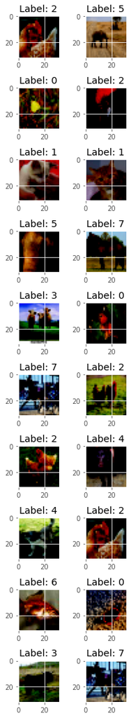

```python
from random import randint

# specify the number of rows and columns you want to see
num_row = 10
num_col = 2
index_lst = []
img_test = []
label_test = []

# get a segment of the dataset
images = data_manager.X_test
labels = data_manager.y_test


# plot images
fig, axes = plt.subplots(num_row, num_col, figsize=(1.5*num_col,1.5*num_row))
for i in range(num_row*num_col):
    index = randint(0,data_manager.X_test.shape[0])
    index_lst.append(index)
    ax = axes[i//num_col, i%num_col]
    ax.imshow(images[index], cmap='gray')
    img_test.append(images[index])
    label_test.append(labels[index])
    ax.set_title('Label: {}'.format(labels[index]))
plt.tight_layout()
plt.show()
```

```python
#fgsm attack
image_samples_adv_fgsm = fgsm_attack(best_model,np.array(img_test),np.array(label_test), epsilon=0.0313)
label_sample_adv_fgsm = np.argmax(best_model(image_samples_adv_fgsm).numpy(), 1)
```

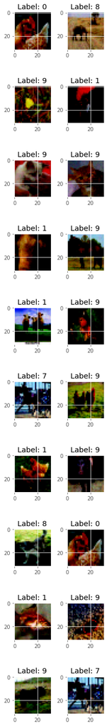

```python
plot_image_grid(10, 2, image_samples_adv_fgsm.numpy(), label_sample_adv_fgsm, (28, 28))
```

```python
y_adv_fgsm = []
y_true_fgsm = []
for i in range(len(index_lst)):

    X_batch_adv_fgsm = fgsm_attack(best_model,np.array(img_test),np.array(label_test), epsilon=0.0313)
    y_batch_adv_fgsm = np.argmax(best_model(X_batch_adv_fgsm).numpy(), 1)
    y_adv_fgsm = y_batch_adv_fgsm
    y_true_fgsm = np.array(label_test)
```

```python
from sklearn.metrics import accuracy_score

test_adv_acc_fgsm = accuracy_score(y_true_fgsm, y_adv_fgsm)
print("Test adv accuracy fgsm attack:{}".format(test_adv_acc_fgsm))
```

```
Test adv accuracy fgsm attack:0.1
```

```python
#pgd attack
image_samples_adv_pgd = pgd_attack(best_model,np.array(img_test),np.double(np.array(label_test)), epsilon=0.0313, num_steps=20, step_size=0.002)
label_sample_adv_pgd = np.argmax(best_model(image_samples_adv_pgd).numpy(), 1)
```

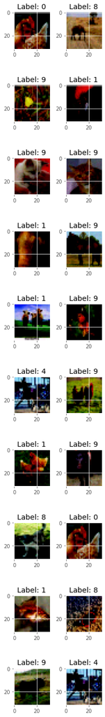

```python
plot_image_grid(10, 2, image_samples_adv_pgd.numpy(), label_sample_adv_pgd, (28, 28))
```

```python
y_adv_pgd = []
y_true_pgd = []
for i in range(len(index_lst)):
    X_batch_adv_pgd = pgd_attack(best_model,np.array(img_test),np.array(label_test), epsilon=0.0313, num_steps=20, step_size=0.002)
    y_batch_adv_pgd = np.argmax(best_model(X_batch_adv_pgd).numpy(), 1)
    y_adv_pgd = y_batch_adv_pgd
    y_true_pgd = np.array(label_test)
```

```python
test_adv_acc_pgd = accuracy_score(y_true_pgd, y_adv_pgd)
print("Test adv accuracy pdg attack:{}".format(test_adv_acc_pgd))
```

```
Test adv accuracy pdg attack:0.0
```

```python
#mim attack
image_samples_adv_mim = mim_attack(best_model,np.array(img_test),np.array(label_test), epsilon=0.0313, num_steps=20, step_size=0.002)
label_sample_adv_mim  = np.argmax(best_model(image_samples_adv_mim).numpy(), 1)
```

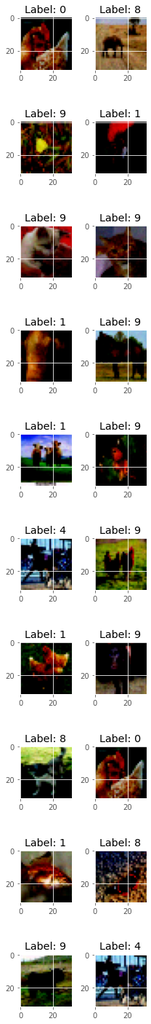

```python
plot_image_grid(10, 2, image_samples_adv_mim.numpy(), label_sample_adv_mim, (28, 28))
```

```python
y_adv_mim = []
y_true_mim = []
for i in range(len(index_lst)):
    X_batch_adv_mim = mim_attack(best_model,np.array(img_test),np.array(label_test), epsilon=0.0313, num_steps=20, step_size=0.002)
    y_batch_adv_mim = np.argmax(best_model(X_batch_adv_mim).numpy(), 1)
    y_adv_mim = y_batch_adv_mim
    y_true_mim = np.array(label_test)
```

```python
test_adv_acc_mim = accuracy_score(y_true_mim, y_adv_mim)
print("Test adv accuracy mim attack:{}".format(test_adv_acc_mim))
```

```
Test adv accuracy mim attack:0.0
```

**Question 3.9** **Train a robust model using adversarial training with PGD ${\epsilon= 0.0313, k=10, \eta= 0.002}$. Write the code for the adversarial training and report the robust accuracies. After finishing the training, you need to store your best robust model in the folder `./models` and load the model to evaluate the robust accuracies for PGD, MIM, and FGSM attacks with $\epsilon= 0.0313, k=20, \eta= 0.002$ on the testing set.**

[5 points]

```python
#Insert your code here. You can add more cells if necessary
optimizer = tf.optimizers.Adam(learning_rate=0.001)
loss_obj = tf.nn.sparse_softmax_cross_entropy_with_logits

# metrics to track the different accuracies.
train_loss = tf.metrics.Mean(name='train_loss')
test_acc_clean = tf.metrics.SparseCategoricalAccuracy()
test_acc_pgd = tf.metrics.SparseCategoricalAccuracy()
```

```python
def train_step_adv(x, x_adv, y):
    with tf.GradientTape() as tape:
        logits = best_model(x)
        logits_adv = best_model(x_adv)
        y = tf.cast(y,tf.int32)
        loss = (loss_obj(y, logits) + loss_obj(y, logits_adv))/2
        gradients = tape.gradient(loss,best_model.trainable_variables)
        optimizer.apply_gradients(zip(gradients, best_model.trainable_variables))
    return loss
```

```python
epochs = 5 # number of epochs
for epoch in range(epochs):
    # keras like display of progress
    progress_bar_train = tf.keras.utils.Progbar(400, verbose=1)
    for i in range(len(index_lst)):

        x = tf.convert_to_tensor(np.array(img_test))
        x = tf.cast(x, tf.float32)

        y = tf.convert_to_tensor(np.array(label_test))
        y = tf.cast(y, tf.float32)

       # replace clean example with adversarial example by 10-steps projected_gradient_descent for adversarial training
        x_adv =  pgd_attack(best_model,x ,y, epsilon=0.0313, num_steps=10, step_size=0.002)
        loss = train_step_adv(x, x_adv, y)
        y_pred = best_model(x)
        test_acc_clean(y, y_pred)
        train_loss(loss)
        progress_bar_train.add(x.shape[0], values=[('loss', train_loss.result()), ("acc (%)", test_acc_clean.result() * 100)])
```

```python
best_model.save('./models/best_model')
```

[output not shown]

```python
prev_model = tf.keras.models.load_model('./models/best_model')
```

```python
y_adv_pgd = []
y_true_pgd = []
for i in range(len(index_lst)):
    X_batch_adv_pgd = pgd_attack(prev_model,np.array(img_test),np.array(label_test), epsilon=0.0313, num_steps=20, step_size=0.002)
    y_batch_adv_pgd = np.argmax(prev_model(X_batch_adv_pgd).numpy(), 1)
    y_adv_pgd = y_batch_adv_pgd
    y_true_pgd = np.array(label_test)
```

```python
test_adv_acc = accuracy_score(y_true_pgd, y_adv_pgd)
print("Test adv accuracy:{}".format(test_adv_acc))
```

```
Test adv accuracy:0.1
```

```python
y_adv_mim = []
y_true_mim = []
for i in range(len(index_lst)):
    X_batch_adv_mim = mim_attack(prev_model,np.array(img_test),np.array(label_test), epsilon=0.0313, num_steps=20, step_size=0.002)
    y_batch_adv_mim = np.argmax(prev_model(X_batch_adv_mim).numpy(), 1)
    y_adv_mim = y_batch_adv_mim
    y_true_mim = np.array(label_test)
```

```python
test_adv_acc_mim = accuracy_score(y_true_mim, y_adv_mim)
print("Test adv accuracy mim attack:{}".format(test_adv_acc_mim))
```

```
Test adv accuracy mim attack:0.1
```

```python
y_adv_fgsm = []
y_true_fgsm = []
for i in range(len(index_lst)):

    X_batch_adv_fgsm = fgsm_attack(prev_model,np.array(img_test),np.array(label_test), epsilon=0.0313)
    y_batch_adv_fgsm = np.argmax(prev_model(X_batch_adv_fgsm).numpy(), 1)
    y_adv_fgsm = y_batch_adv_fgsm
    y_true_fgsm = np.array(label_test)
```

```python
test_adv_acc_fgsm = accuracy_score(y_true_fgsm, y_adv_fgsm)
print("Test adv accuracy fgsm attack:{}".format(test_adv_acc_fgsm))
```

```
Test adv accuracy fgsm attack:0.1
```

The following is an exploring question with bonus points. It is great if you try to do this question, but it is **totally optional**. In this question, we will investigate a recent SOTA technique to improve the generalization ability of deep nets named *Sharpness-Aware Minimization (SAM)* ([link to the main paper](https://openreview.net/pdf?id=6Tm1mposlrM)). Furthermore, SAM is simple and efficient technique, but roughly doubles the training time due to its required computation. If you have an idea to improve SAM, it would be a great paper to top-tier venues in machine learning and computer vision. Highly recommend to give it a try.

**Question 3.10** (**additionally exploring question**) Read the SAM paper ([link to the main paper](https://openreview.net/pdf?id=6Tm1mposlrM)). Try to apply this techique to the best obtained model and report the results. For the purpose of implementating SAM, we can flexibly add more cells and extensions to the `model.py` file.

[5 points]

```python
#Insert your code here. You can add more cells if necessary
```

END OF ASSIGNMENT

GOOD LUCK WITH YOUR ASSIGNMENT 1!